# Temporal modelling for MercyHospital

Author

Fernando Mayer, Niamh Cahill, Niamh Mimnagh

Published

October 10, 2026

# Data for MercyHospital

This page presents the temporal modelling of tidal characteristics at MercyHospital.

The analysis uses tidal features estimated from three-year rolling windows, including Highest Astronomical Tide (HAT), Mean High Water Springs (MHWS), Mean High Water Neaps (MHWN), Mean Sea Level (MSL), Mean Low Water Neaps (MLWN), Mean Low Water Springs (MLWS), and Lowest Astronomical Tide (LAT).

A series of Bayesian temporal models are fitted using INLA to investigate how these tidal characteristics vary through time. The models consider different combinations of long-term temporal trends, unstructured year-to-year variation, and structured temporal dependence.

```r
## Packages
library(arrow)
library(tidyverse)
library(patchwork)
library(TideHarmonics)
library(INLA)
here::i_am("index.qmd")
source(here::here("scripts", "_functions.R"))
theme_set(theme_bw() + theme(legend.position = "right", legend.direction = "vertical"))

## Full dataset
fl <- here::here("rds", sprintf("features-%s.rds", params$station))
da <- readRDS(fl)

## Set the levels for constituents
const_levels <- c("HAT","MHWS", "MHWN", "MSL", "MLWN", "MLWS","LAT")
## Select the windown interval
ws <- "y_3"
## Define years to predict
yrs <- range(da$year_mid) + c(-10, 10)
yrs_seq <- seq(yrs[1], yrs[2])

## Before splitting, rearrange and remove columns. ALSO, filter for window size
da <- da |>
    filter(window_size == ws) |>
    select(year_start, year_mid, year_end, constituent, value, st_id, lat, lon)

## Split by constituent and create a list
db <- da |>
    split(~constituent)

## Arrange and complete with more years
db <- imap(db, \(x, nm) {
    x |>
        arrange(year_mid) |>
        complete(year_mid = yrs_seq,
            fill = list(
                constituent = nm,
                st_id = unique(x$st_id)[1],
                lat = unique(x$lat)[1],
                lon = unique(x$lon)[1]
            )) |>
        mutate(constituent = fct_relevel(constituent, const_levels),
            id = seq_along(year_mid), id2 = id, id3 = id)
})
```

# Exploratory analysis

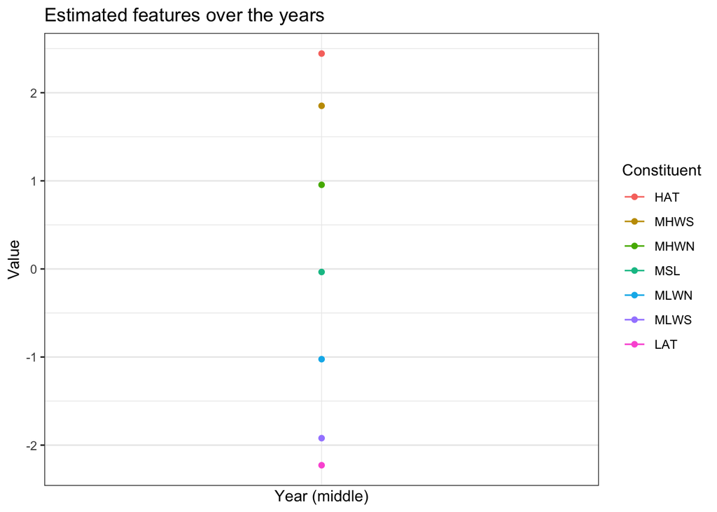

```r
db |>
    bind_rows() |>
    filter(!is.na(value)) |>
    ggplot(aes(x = make_datetime(year_mid), y = value, color = constituent)) +
    geom_line() +
    geom_point() +
    scale_x_datetime(
        date_breaks = "2 year",
        date_minor_breaks = "1 year",
        date_labels = "%Y") +
    labs(x = "Year (middle)", y = "Value",
        title = "Estimated features over the years",
        color = "Constituent")
```

# Models

A set of twelve temporal models is fitted to each tidal feature. The models differ in whether they include a temporal trend and in the structure used to represent additional temporal variation. This allows models ranging from a simple constant mean to models containing a deterministic trend together with structured and/or unstructured temporal effects to be compared.

The components used in the models are:

- **Intercept (`1`)**: represents the overall mean level of the tidal feature across the study period.
- **Trend (`id`)**: represents a linear change in the tidal feature through time.
- **IID effect (`f(id2, model = "iid")`)**: represents unstructured temporal variability. Values for different time points are treated as independent, allowing individual years to deviate from the overall mean or trend without assuming temporal dependence between those deviations.
- **AR(1) effect (`f(id3, model = "ar1")`)**: represents temporally correlated variation using a first-order autoregressive process. Values at neighbouring time points are allowed to be more similar, with the temporal dependence decreasing as the separation between time points increases.
- **RW1 effect (`f(id3, model = "rw1")`)**: represents smoothly varying temporal change using a first-order random walk. Consecutive temporal effects are encouraged to be similar, allowing the underlying level to evolve gradually through time.

The twelve candidate models are:

| Model | Formula | Description |
| --- | --- | --- |
| **m1: Intercept only** | `value ~ 1` | Assumes that the tidal feature has a constant mean through time, with no additional temporal structure. |
| **m2: Intercept + IID** | `value ~ 1 + f(id2, model = "iid")` | Assumes a constant overall mean while allowing independent year-to-year deviations from that mean. |
| **m3: Intercept + AR(1)** | `value ~ 1 + f(id3, model = "ar1")` | Assumes a constant overall mean with temporally correlated deviations, so neighbouring time points can have similar values. |
| **m4: Intercept + RW1** | `value ~ 1 + f(id3, model = "rw1")` | Assumes a constant overall mean together with a smoothly evolving temporal effect represented by a first-order random walk. |
| **m5: Intercept + IID + AR(1)** | `value ~ 1 + f(id2, model = "iid") + f(id3, model = "ar1")` | Combines unstructured temporal variability with temporally correlated variation around a constant overall mean. |
| **m6: Intercept + IID + RW1** | `value ~ 1 + f(id2, model = "iid") + f(id3, model = "rw1")` | Combines independent year-to-year variability with a smoothly evolving temporal component around a constant overall mean. |
| **m7: Linear trend** | `value ~ 1 + id` | Includes a linear temporal trend, allowing the expected tidal feature to systematically increase or decrease through time. |
| **m8: Trend + IID** | `value ~ 1 + id + f(id2, model = "iid")` | Includes a linear temporal trend together with independent deviations around that trend. |
| **m9: Trend + AR(1)** | `value ~ 1 + id + f(id3, model = "ar1")` | Includes a linear temporal trend together with temporally correlated deviations around the trend. |
| **m10: Trend + RW1** | `value ~ 1 + id + f(id3, model = "rw1")` | Includes a linear temporal trend together with additional smoothly varying temporal change represented by a first-order random walk. |
| **m11: Trend + IID + AR(1)** | `value ~ 1 + id + f(id2, model = "iid") + f(id3, model = "ar1")` | Includes a linear trend, independent temporal variability, and temporally correlated variability. |
| **m12: Trend + IID + RW1** | `value ~ 1 + id + f(id2, model = "iid") + f(id3, model = "rw1")` | Includes a linear trend, independent temporal variability, and a smoothly evolving temporal component. |

Together, these models allow several possible forms of temporal behaviour to be considered. Models m1–m6 assume no systematic linear trend, whereas models m7–m12 explicitly include a linear trend. Within each group, the models progressively allow for unstructured temporal variation (IID), temporally correlated variation (AR(1)), smoothly evolving temporal variation (RW1), or combinations of these components.

## Model fitting checks and safeguards

Before fitting the temporal models, the amount of information available for each tidal feature is assessed. Temporal models are fitted only when a feature has at least five non-missing rolling-window estimates and at least three distinct observed values. These checks prevent temporal models from being fitted to extremely short series or to series that are effectively constant and so contain insufficient information to estimate temporal structure.

The complexity of the candidate model set is also adjusted according to the length of the available time series. When fewer than 15 non-missing temporal observations are available, models containing two simultaneous random-effect components are omitted. Specifically, the following models are excluded for shorter series:

- m5: intercept + IID + AR(1)
- m6: intercept + IID + RW1
- m11: trend + IID + AR(1)
- m12: trend + IID + RW1

These models contain both an unstructured IID component and a structured temporal component. When few observations are available, these can be difficult to identify and the models can become unstable. Shorter series are fitted using the reduced set of eight candidate models, while series containing at least 15 observations are fitted using the full set of twelve models.

The models are fitted using INLA with Gaussian observation errors. Because some of the temporal series are short and some of the more flexible models can be numerically challenging, a fitting procedure is used to ensure models are fitted successfully wherever possible. Each model is initially fitted using the standard INLA optimisation settings. If this attempt fails, the model is refitted using progressively smaller Newton–Raphson step sizes and additional optimiser restarts. A model is excluded only if all three fitting attempts fail.

If none of the candidate models can be fitted successfully, the feature is recorded as having no available temporal model rather than terminating the analysis for the entire station.

The final model-fit summary records, for each tidal feature, the number of temporal observations and unique values available, whether temporal modelling was possible, the number of models successfully fitted, and the specific candidate models retained for subsequent comparison.

```r
## Define formulas
form <- gen_model_formulas()
form_levels <- names(form)

## Minimum amount of temporal information required
## A station/constituent must have at least this many non-missing rolling-window
## estimates before the temporal INLA models are fitted.
MIN_TEMPORAL_OBS <- 5

## Also require at least three distinct values. This prevents temporal models
## being fitted to a series that is effectively constant.
MIN_UNIQUE_VALUES <- 3

## Threshold for using the full model set
## For short temporal series, models containing two simultaneous random effects
## can be weakly identified and numerically unstable.
## When fewer than 15 observations are available, omit:
##
##   m5  = intercept + iid + ar1
##   m6  = intercept + iid + rw1
##   m11 = trend + iid + ar1
##   m12 = trend + iid + rw1
MIN_OBS_FULL_MODEL_SET <- 15

## Summarise the amount of information available for each tidal level
temporal_data_check <- purrr::imap_dfr(db, \(dc, const) {
       values <- dc$value[!is.na(dc$value)]

        tibble(constituent = const, n_obs = length(values), n_unique = dplyr::n_distinct(values),
            value_sd = ifelse( length(values) > 1,  sd(values),NA_real_ ),
            fit_temporal_model = length(values) >= MIN_TEMPORAL_OBS & dplyr::n_distinct(values) >= MIN_UNIQUE_VALUES)
    }
)

## Create storage object
## Each constituent initially contains NULL. Models are added only when enough
## temporal observations are available.
res <- vector(mode = "list",length = length(const_levels))
names(res) <- const_levels

## INLA settings
cc <- list(cpo = TRUE, waic = TRUE, dic = TRUE, config = TRUE)

## Robust INLA fitting function
## Short temporal series can occasionally cause the Newton-Raphson optimiser
## to fail. Try increasingly conservative optimisation settings before giving
## up on an individual model.

fit_inla_robust <- function(formula, data, control_compute, station, constituent, model_name) {
    ## Attempt 1: normal fit using one thread
    fit <- tryCatch(
        inla(formula = formula, family = "gaussian", data = data, control.compute = control_compute, num.threads = 1),
        error = function(e) {
            NULL
        }
    )

    if (!is.null(fit)) {
        return(fit)
    }

    ## Attempt 2: smaller Newton-Raphson steps
    fit <- tryCatch(
        inla(formula = formula, family = "gaussian", data = data, control.compute = control_compute, num.threads = 1,
            control.inla = list(step.factor = 0.25, restart = 2)),
        error = function(e) {
            NULL
        }
    )

    if (!is.null(fit)) {
        return(fit)
    }

    ## Attempt 3: even smaller Newton-Raphson steps
    fit <- tryCatch(
        inla(formula = formula, family = "gaussian", data = data, control.compute = control_compute, num.threads = 1,
            control.inla = list(step.factor = 0.10, restart = 3)),

        error = function(e) {
              NULL
        }
    )

    ## Return result
    ## If all three attempts failed this will return NULL.
    if (is.null(fit)) {
        message(sprintf(paste0("All fitting attempts failed for %s | %s | %s. ", "This model will be excluded."),station, constituent, model_name))
    }
    fit
}

## Saved model file
fl <- here::here("rds", sprintf("tide-models-%s-all-lat-hat.rds", params$station))

## Fit models
if (!file.exists(fl)) {
    for (const in const_levels) {
        ## Data for this tidal level
        dc <- db[[const]]
        n_obs <- sum(!is.na(dc$value))
        n_unique <- dplyr::n_distinct(dc$value[!is.na(dc$value)])

        ## Check whether enough temporal information is available
        if (n_obs < MIN_TEMPORAL_OBS || n_unique < MIN_UNIQUE_VALUES) {
            message(sprintf(paste0("Skipping temporal models for %s at %s: ", "%i non-missing observations and %i unique values."), const, params$station, n_obs, n_unique))

            ## Preserve constituent name but record that no models were fitted
            res[const] <- list(NULL)
            next
        }

        ## Choose model set according to number of observations
        ## Short series: remove models containing two simultaneous random effects.
        ## Longer series: retain the full set of 12 models.

        if (n_obs < MIN_OBS_FULL_MODEL_SET) {
            form_use <- form[!names(form) %in% c("m5_int_iid_ar1", "m6_int_iid_rw1", "m11_trend_iid_ar1", "m12_trend_iid_rw1")]

            message(sprintf(paste0("%s | %s has %i observations: ", "using reduced temporal model set."), params$station, const, n_obs))
        } else {
            form_use <- form
        }

        ## Report which models will be fitted
        message(sprintf("%s | %s: fitting %i temporal models: %s", params$station, const, length(form_use), paste(names(form_use), collapse = ", ")))

        ## Create model storage for this tidal level
        res[[const]] <- vector(mode = "list", length = length(form_use))
        names(res[[const]]) <- names(form_use)

        ## Fit temporal models
        for (j in seq_along(form_use)) {
            model_name <- names(form_use)[j]

            message(sprintf(paste0("========== Running model for %s: %s ", "| n = %i =========="), const, model_name, n_obs))

            ## Detailed diagnostics printed to terminal
            cat("\n\n",
                "============================================================\n",
                "STATION:     ", params$station, "\n",
                "CONSTITUENT: ", const, "\n",
                "MODEL:       ", model_name, "\n",
                "FORMULA:     ",
                paste(deparse(form_use[[j]]), collapse = " "),
                "\n",
                "N OBS:       ", n_obs, "\n",
                "N UNIQUE:    ", n_unique, "\n",
                "============================================================\n\n",
                sep = ""
            )

            flush.console()

            ## Try progressively more conservative INLA optimisation
            fit_attempt <- fit_inla_robust(
                formula = form_use[[j]],
                data = dc,
                control_compute = cc,
                station = params$station,
                constituent = const,
                model_name = model_name)


            ## Store result
            res[[const]][j] <- list(fit_attempt)
        }

        ## Identify models that failed
        model_ok <- !purrr::map_lgl(res[[const]], is.null)

        if (any(!model_ok)) {
            message(sprintf("%s | %s: %i of %i attempted temporal models failed.", params$station, const, sum(!model_ok), length(model_ok)))

            message(paste("Failed models:", paste(names(res[[const]])[!model_ok],collapse = ", ")))
        }

        ## Keep only successfully fitted models
        res[[const]] <- res[[const]][model_ok]

        ## If absolutely every attempted model failed, preserve a named NULL constituent so the results page knows that no models are available.
        if (length(res[[const]]) == 0) {
            res[const] <- list(NULL)
        }
    }

    ## Save models after all constituents have been processed
    saveRDS(res, fl)

} else {
    res <- readRDS(fl)
}

## Show what was fitted
## Show what was fitted
model_fit_status <- temporal_data_check |>
  transmute(constituent, n_obs, n_unique,
    temporal_models_fitted = purrr::map_lgl(constituent, \(const) {
      models <- res[[const]]
      !is.null(models) && length(models) > 0
    }),
    n_models_fitted = purrr::map_int(constituent, \(const) {
      models <- res[[const]]
      if (is.null(models) || length(models) == 0) 0L else length(models)
    }),
    fitted_models = purrr::map_chr(constituent, \(const) {
      models <- res[[const]]
      if (is.null(models) || length(models) == 0) {
        NA_character_
      } else {
        stringr::str_extract(names(models), "^m\\d+") |>
          paste(collapse = ", ")
      }
    })) |>
  rename(
    `Tidal feature` = constituent,
    `Observations` = n_obs,
    `Unique values` = n_unique,
    `Models fitted` = temporal_models_fitted,
    `Number fitted` = n_models_fitted,
    `Fitted model set` = fitted_models
  )

model_fit_status |>
  knitr::kable(
    format = "html",
    align = c("l", "c", "c", "c", "c", "l"),
    caption = "Temporal model fitting summary"
  ) |>
  kableExtra::kable_styling(
    full_width = TRUE,
    bootstrap_options = c("striped", "hover", "condensed")
  ) |>
  kableExtra::column_spec(1, width = "110px") |>
  kableExtra::column_spec(2:5, width = "100px") |>
  kableExtra::column_spec(6, width = "300px") |>
  kableExtra::scroll_box(height = "500px", fixed_thead = TRUE)
```

Temporal model fitting summary

| Tidal feature | Observations | Unique values | Models fitted | Number fitted | Fitted model set |
| --- | --- | --- | --- | --- | --- |
| HAT | 1 | 1 | FALSE | 0 | NA |
| MHWS | 1 | 1 | FALSE | 0 | NA |
| MHWN | 1 | 1 | FALSE | 0 | NA |
| MSL | 1 | 1 | FALSE | 0 | NA |
| MLWN | 1 | 1 | FALSE | 0 | NA |
| MLWS | 1 | 1 | FALSE | 0 | NA |
| LAT | 1 | 1 | FALSE | 0 | NA |

# Results

**HAT**

```r
show_temporal_results(
    "HAT",
    res,
    db
)
```

**Temporal modelling was not performed for HAT.** Only 1 non-missing temporal estimates were available; at least 5 are required for temporal modelling.

**MHWS**

```r
show_temporal_results(
    "MHWS",
    res,
    db
)
```

**Temporal modelling was not performed for MHWS.** Only 1 non-missing temporal estimates were available; at least 5 are required for temporal modelling.

**MHWN**

```r
show_temporal_results(
    "MHWN",
    res,
    db
)
```

**Temporal modelling was not performed for MHWN.** Only 1 non-missing temporal estimates were available; at least 5 are required for temporal modelling.

**MSL**

```r
show_temporal_results(
    "MSL",
    res,
    db
)
```

**Temporal modelling was not performed for MSL.** Only 1 non-missing temporal estimates were available; at least 5 are required for temporal modelling.

**MLWN**

```r
show_temporal_results(
    "MLWN",
    res,
    db
)
```

**Temporal modelling was not performed for MLWN.** Only 1 non-missing temporal estimates were available; at least 5 are required for temporal modelling.

**MLWS**

```r
show_temporal_results(
    "MLWS",
    res,
    db
)
```

**Temporal modelling was not performed for MLWS.** Only 1 non-missing temporal estimates were available; at least 5 are required for temporal modelling.

**LAT**

```r
show_temporal_results(
    "LAT",
    res,
    db
)
```

**Temporal modelling was not performed for LAT.** Only 1 non-missing temporal estimates were available; at least 5 are required for temporal modelling.

```r
fl <- here::here("rds", sprintf("inla-st-data-%s.rds", params$station))

## Make db a full tibble
dc <- db |>
    bind_rows() |>
    select(-c(id, id2, id3)) |>
    mutate(constituent = factor(as.character(constituent), levels = const_levels))

saveRDS(dc, fl)
```